# Assignment3: Esoph and Youth Survey

Barış Sivas

19 12 2020

# 1.Esoph Analysis

## 1.1 Preparation to The Data Analysis

There are some kind of packages that could be used in both analysis downloaded firstly.

```r
library(tidyverse)
library(rio)
library(ggplot2)
library(dplyr)
library(lubridate)
```

With the aim of understanding what the data includes, a quick snapshot was taken as shown below. The data tells about the age distribution of the people who had an issue about cancer disease(cases or controls) with their alcohol and tobacco usage routines.

```r
head(esoph, 10)
```

```
##    agegp     alcgp    tobgp ncases ncontrols
## 1  25-34 0-39g/day 0-9g/day      0        40
## 2  25-34 0-39g/day    10-19      0        10
## 3  25-34 0-39g/day    20-29      0         6
## 4  25-34 0-39g/day      30+      0         5
## 5  25-34     40-79 0-9g/day      0        27
## 6  25-34     40-79    10-19      0         7
## 7  25-34     40-79    20-29      0         4
## 8  25-34     40-79      30+      0         7
## 9  25-34    80-119 0-9g/day      0         2
## 10 25-34    80-119    10-19      0         1
```

```r
summary(esoph)
```

```
##    agegp          alcgp         tobgp        ncases         ncontrols
##  25-34:15   0-39g/day:23   0-9g/day:24   Min.   : 0.000   Min.   : 1.00
##  35-44:15   40-79    :23   10-19   :24   1st Qu.: 0.000   1st Qu.: 3.00
##  45-54:16   80-119   :21   20-29   :20   Median : 1.000   Median : 6.00
##  55-64:16   120+     :21   30+     :20   Mean   : 2.273   Mean   :11.08
##  65-74:15                                3rd Qu.: 4.000   3rd Qu.:14.00
##  75+  :11                                Max.   :17.000   Max.   :60.00
```

## 1.2. Distribution of The Cancer Case Among Age Groups

```r
dt1<- esoph %>%
  group_by(agegp)%>%
  summarise(total_ncases = sum(ncases), total_control = sum(ncontrols))%>%
  mutate(Cancer_Rate = round(total_ncases*100/total_control))%>%
  arrange(desc(Cancer_Rate))

  dt1
```

```
## # A tibble: 6 x 4
##   agegp total_ncases total_control Cancer_Rate
##   <ord>        <dbl>         <dbl>       <dbl>
## 1 65-74           55           161          34
## 2 55-64           76           242          31
## 3 75+             13            44          30
## 4 45-54           46           213          22
## 5 35-44            9           199           5
## 6 25-34            1           116           1
```

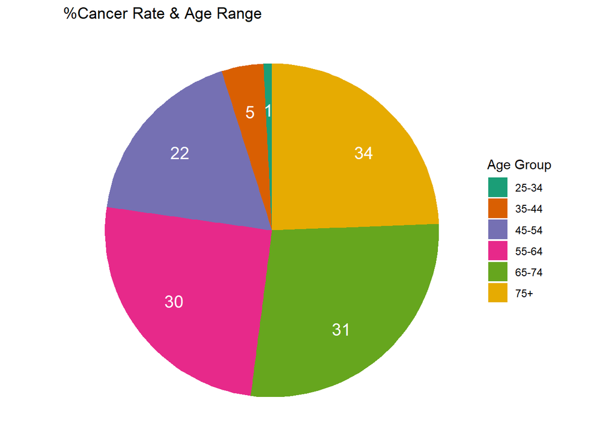

```r
ggplot(dt1, aes(x="", y=Cancer_Rate,"%", fill=agegp)) + geom_bar(stat="identity") +
  geom_text(aes(x= 1.2, y = Cancer_Rate/2 + c(0, cumsum(Cancer_Rate)[-length(Cancer_Rate)]), label = Cancer_Rate),  size=5, color = "white")+
  coord_polar(theta = "y") +
  scale_fill_brewer(palette = "Dark2")+
  theme_void()+
  labs(title = "%Cancer Rate & Age Range", fill = "Age Group")
```

## 1.3. Relationship Between The Cancer Case and Alcohol Consumption

This analyse sents a warn message to the people who takes 120 g alcohol per a day. Unfortunately high level alcohol consumption could be deadly especially for people who are older than 45 years old.

```r
dt2<- esoph %>%
  group_by(agegp,alcgp)%>%
  summarise(total_ncases = sum(ncases), total_control = sum(ncontrols))%>%
  mutate(Cancer_Rate = total_ncases*100/ total_control)%>%
  arrange(desc(Cancer_Rate))

  dt2
```

```
## # A tibble: 24 x 5
## # Groups:   agegp [6]
##    agegp alcgp  total_ncases total_control Cancer_Rate
##    <ord> <ord>         <dbl>         <dbl>       <dbl>
##  1 75+   80-119            2             2       100
##  2 75+   120+              3             3       100
##  3 45-54 120+             13            15        86.7
##  4 65-74 120+              6             8        75
##  5 55-64 120+             18            26        69.2
##  6 55-64 80-119           24            43        55.8
##  7 65-74 40-79            25            53        47.2
##  8 65-74 80-119           13            29        44.8
##  9 35-44 120+              4            10        40
## 10 75+   40-79             4            12        33.3
## # ... with 14 more rows
```

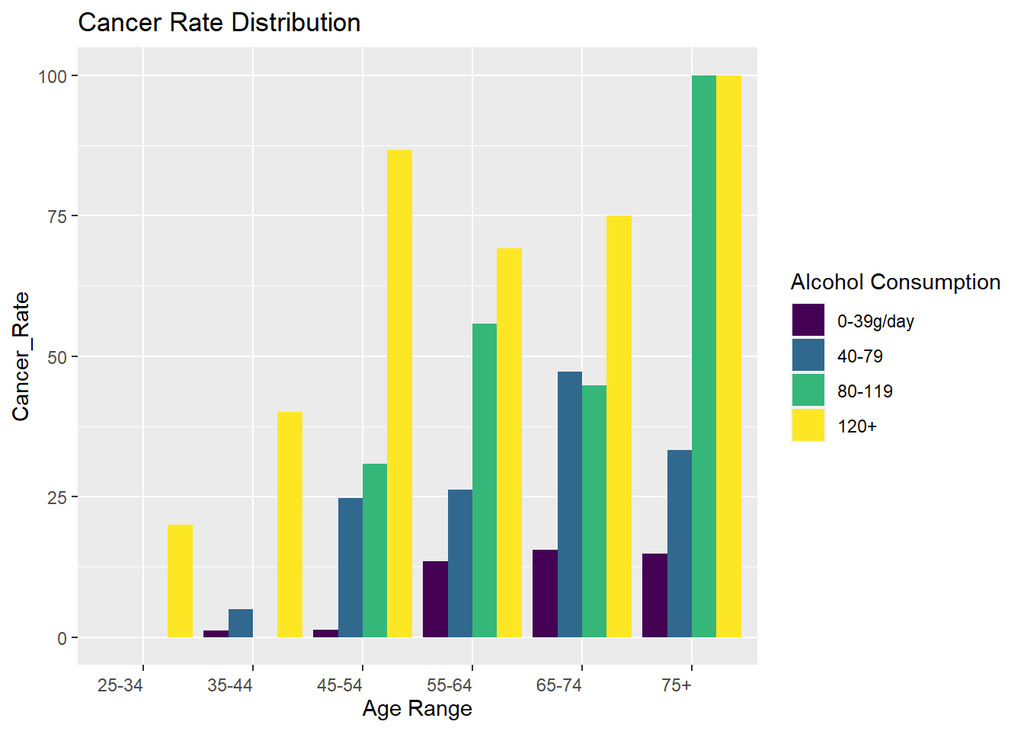

```r
  ggplot(dt2, aes(x = agegp, y = Cancer_Rate, fill= alcgp))+
  geom_bar(stat="identity", position = "dodge" ) +theme(axis.text.x = element_text(angle=0, size=9, vjust=0.5,hjust=1)) +
    labs(title = "Cancer Rate Distribution", x = "Age Range", fill="Alcohol Consumption")
```

## 1.4. Relationship Between The Cancer Case and Tobacco Consumption

This analyse also sents a warn message to the people who takes 30 g tobacco per a day. It could be more dangerous especially for people who are older than 45 years old.

```r
dt3<- esoph %>%
  group_by(agegp,tobgp)%>%
  summarise(total_ncases = sum(ncases), total_control = sum(ncontrols))%>%
  mutate(Cancer_Rate = total_ncases*100/ total_control)%>%
  arrange(desc(Cancer_Rate))

  dt3
```

```
## # A tibble: 24 x 5
## # Groups:   agegp [6]
##    agegp tobgp    total_ncases total_control Cancer_Rate
##    <ord> <ord>           <dbl>         <dbl>       <dbl>
##  1 55-64 30+                16            22        72.7
##  2 45-54 30+                11            19        57.9
##  3 65-74 20-29              10            20        50
##  4 65-74 30+                 2             4        50
##  5 75+   30+                 2             4        50
##  6 75+   10-19               5            11        45.5
##  7 55-64 10-19              23            65        35.4
##  8 55-64 20-29              12            38        31.6
##  9 65-74 10-19              12            38        31.6
## 10 65-74 0-9g/day           31            99        31.3
## # ... with 14 more rows
```

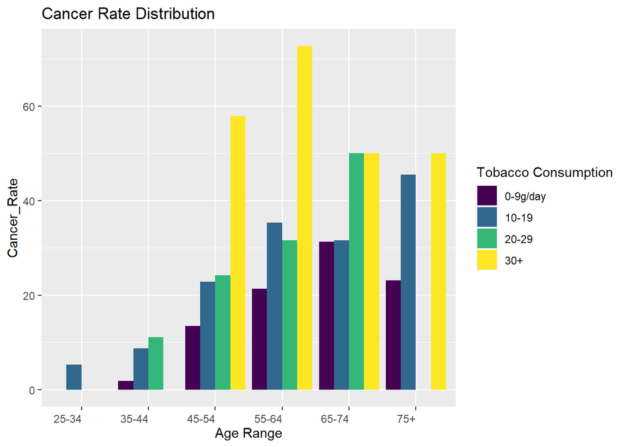

```r
  ggplot(dt3, aes(x = agegp, y = Cancer_Rate, fill= tobgp))+
  geom_bar(stat="identity", position = "dodge") +theme(axis.text.x = element_text(angle=0, size=9, vjust=0.5,hjust=1)) +
    labs(title = "Cancer Rate Distribution", x = "Age Range",fill="Tobacco Consumption")
```

## 1.5. Effectivness of Both Alcohol and Tobacco Consumption

```r
dt3<- esoph %>%
  group_by(agegp,alcgp, tobgp)%>%
  summarise(total_ncases = sum(ncases), total_control = sum(ncontrols))%>%
  mutate(Cancer_Rate = total_ncases*100/ total_control)%>%
  arrange(desc(Cancer_Rate))

  dt2
```

```
## # A tibble: 24 x 5
## # Groups:   agegp [6]
##    agegp alcgp  total_ncases total_control Cancer_Rate
##    <ord> <ord>         <dbl>         <dbl>       <dbl>
##  1 75+   80-119            2             2       100
##  2 75+   120+              3             3       100
##  3 45-54 120+             13            15        86.7
##  4 65-74 120+              6             8        75
##  5 55-64 120+             18            26        69.2
##  6 55-64 80-119           24            43        55.8
##  7 65-74 40-79            25            53        47.2
##  8 65-74 80-119           13            29        44.8
##  9 35-44 120+              4            10        40
## 10 75+   40-79             4            12        33.3
## # ... with 14 more rows
```

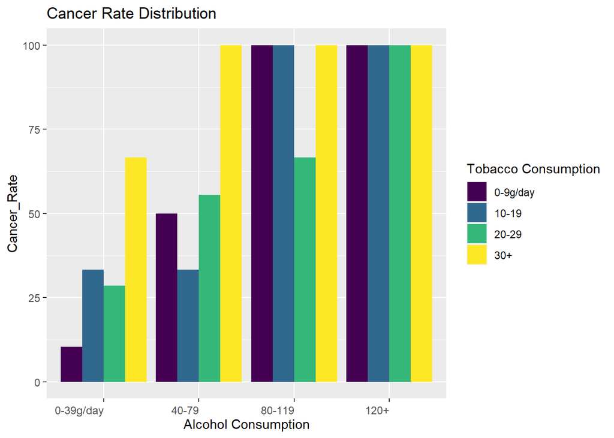

```r
  ggplot(dt3, aes(x = alcgp, y = Cancer_Rate, fill= tobgp))+
  geom_bar(stat="identity", position = "dodge") +theme(axis.text.x = element_text(angle=0, size=9, vjust=0.5,hjust=1)) +
    labs(title = "Cancer Rate Distribution", x = "Alcohol Consumption", fill = "Tobacco Consumption")
```

# 2.Young People Response Analysis

## 2.1. Preparation to The Data Analysis

```r
 ys<- rio::import("https://github.com/pjournal/mef04-sivasbaris/blob/gh-pages/young_people_responses.csv?raw=True")

raw_ys<- na.omit(ys)
glimpse(raw_ys)
```

```
## Rows: 686
## Columns: 150
## $ Music                            <int> 5, 4, 5, 5, 5, 5, 5, 5, 5, 5, 5, 5...
## $ `Slow songs or fast songs`       <int> 3, 4, 5, 3, 3, 5, 3, 3, 3, 3, 3, 3...
## $ Dance                            <int> 2, 2, 2, 4, 2, 5, 3, 2, 3, 1, 1, 5...
## $ Folk                             <int> 1, 1, 2, 3, 3, 3, 2, 5, 2, 1, 2, 3...
## $ Country                          <int> 2, 1, 3, 2, 2, 1, 1, 2, 1, 1, 1, 2...
## $ `Classical music`                <int> 2, 1, 4, 4, 3, 2, 2, 2, 2, 4, 4, 1...
## $ Musical                          <int> 1, 2, 5, 3, 3, 2, 2, 5, 3, 1, 3, 5...
## $ Pop                              <int> 5, 3, 3, 5, 2, 5, 4, 3, 4, 2, 3, 5...
## $ Rock                             <int> 5, 5, 5, 3, 5, 3, 5, 5, 3, 5, 5, 2...
## $ `Metal or Hardrock`              <int> 1, 4, 3, 1, 5, 1, 1, 2, 2, 1, 4, 1...
## $ Punk                             <int> 1, 4, 4, 2, 3, 1, 2, 3, 1, 1, 2, 1...
## $ `Hiphop, Rap`                    <int> 1, 1, 1, 5, 4, 3, 3, 2, 3, 1, 3, 2...
## $ `Reggae, Ska`                    <int> 1, 3, 4, 3, 3, 1, 2, 4, 2, 1, 1, 1...
```

[output cut: 137 more lines]

## 2.2. Selecting Data

After taking a snapshot to cleaned data, the rows between 32 to 63 which were assigned as History: Pets was selected.

```r
survey_df = as.data.frame(raw_ys)
survey_data = survey_df[32:63]
head(survey_data)
```

```
##   History Psychology Politics Mathematics Physics Internet PC
## 1       1          5        1           3       3        5  3
## 2       1          3        4           5       2        4  4
## 3       1          2        1           5       2        4  2
## 5       3          2        3           2       2        2  2
## 6       5          3        4           2       3        4  4
## 7       3          3        1           1       1        2  1
##   Economy Management Biology Chemistry Reading Geography Foreign languages
## 1                  5       3         3       3         3                 5
## 2                  5       1         1       4         4                 5
## 3                  4       1         1       5         2                 5
## 5                  2       3         3       5         2                 3
## 6                  1       4         4       3         3                 4
## 7                  3       5         5       3         3                 4
##   Medicine Law Cars Art exhibitions Religion Countryside, outdoors Dancing
```

[output cut: 27 more lines]

```r
summary(survey_data)
```

```
##     History        Psychology      Politics      Mathematics       Physics
##  Min.   :1.000   Min.   :1.00   Min.   :1.000   Min.   :1.000   Min.   :1.000
##  1st Qu.:2.000   1st Qu.:2.00   1st Qu.:2.000   1st Qu.:1.000   1st Qu.:1.000
##  Median :3.000   Median :3.00   Median :3.000   Median :2.000   Median :2.000
##  Mean   :3.226   Mean   :3.14   Mean   :2.627   Mean   :2.401   Mean   :2.096
##  3rd Qu.:4.000   3rd Qu.:4.00   3rd Qu.:4.000   3rd Qu.:3.000   3rd Qu.:3.000
##  Max.   :5.000   Max.   :5.00   Max.   :5.000   Max.   :5.000   Max.   :5.000
##     Internet           PC        Economy Management    Biology
##  Min.   :1.000   Min.   :1.000   Min.   :1.000      Min.   :1.000
##  1st Qu.:4.000   1st Qu.:2.000   1st Qu.:1.000      1st Qu.:1.000
##  Median :4.000   Median :3.000   Median :2.000      Median :2.000
##  Mean   :4.188   Mean   :3.136   Mean   :2.662      Mean   :2.621
##  3rd Qu.:5.000   3rd Qu.:4.000   3rd Qu.:4.000      3rd Qu.:4.000
##  Max.   :5.000   Max.   :5.000   Max.   :5.000      Max.   :5.000
##    Chemistry        Reading      Geography     Foreign languages
##  Min.   :1.000   Min.   :1.0   Min.   :1.000   Min.   :1.000
##  1st Qu.:1.000   1st Qu.:2.0   1st Qu.:2.000   1st Qu.:3.000
##  Median :2.000   Median :3.0   Median :3.000   Median :4.000
##  Mean   :2.121   Mean   :3.2   Mean   :3.109   Mean   :3.813
##  3rd Qu.:3.000   3rd Qu.:5.0   3rd Qu.:4.000   3rd Qu.:5.000
##  Max.   :5.000   Max.   :5.0   Max.   :5.000   Max.   :5.000
##     Medicine          Law             Cars       Art exhibitions
##  Min.   :1.000   Min.   :1.000   Min.   :1.000   Min.   :1.000
##  1st Qu.:1.000   1st Qu.:1.000   1st Qu.:1.000   1st Qu.:1.000
##  Median :2.000   Median :2.000   Median :2.000   Median :2.000
##  Mean   :2.475   Mean   :2.224   Mean   :2.634   Mean   :2.617
##  3rd Qu.:3.000   3rd Qu.:3.000   3rd Qu.:4.000   3rd Qu.:4.000
##  Max.   :5.000   Max.   :5.000   Max.   :5.000   Max.   :5.000
##     Religion     Countryside, outdoors    Dancing      Musical instruments
##  Min.   :1.000   Min.   :1.000         Min.   :1.000   Min.   :1.000
##  1st Qu.:1.000   1st Qu.:3.000         1st Qu.:1.000   1st Qu.:1.000
##  Median :2.000   Median :4.000         Median :2.000   Median :2.000
##  Mean   :2.229   Mean   :3.614         Mean   :2.399   Mean   :2.302
##  3rd Qu.:3.000   3rd Qu.:5.000         3rd Qu.:3.000   3rd Qu.:3.000
##  Max.   :5.000   Max.   :5.000         Max.   :5.000   Max.   :5.000
##     Writing      Passive sport    Active sport     Gardening
##  Min.   :1.000   Min.   :1.000   Min.   :1.000   Min.   :1.000
##  1st Qu.:1.000   1st Qu.:2.000   1st Qu.:2.000   1st Qu.:1.000
##  Median :1.000   Median :4.000   Median :3.000   Median :1.000
##  Mean   :1.866   Mean   :3.394   Mean   :3.236   Mean   :1.872
##  3rd Qu.:2.000   3rd Qu.:5.000   3rd Qu.:5.000   3rd Qu.:2.000
##  Max.   :5.000   Max.   :5.000   Max.   :5.000   Max.   :5.000
##   Celebrities       Shopping     Science and technology    Theatre
##  Min.   :1.000   Min.   :1.000   Min.   :1.000          Min.   :1.000
##  1st Qu.:1.000   1st Qu.:2.000   1st Qu.:2.000          1st Qu.:2.000
##  Median :2.000   Median :3.000   Median :3.000          Median :3.000
##  Mean   :2.319   Mean   :3.257   Mean   :3.271          Mean   :3.023
##  3rd Qu.:3.000   3rd Qu.:4.000   3rd Qu.:4.000          3rd Qu.:4.000
##  Max.   :5.000   Max.   :5.000   Max.   :5.000          Max.   :5.000
##  Fun with friends Adrenaline sports      Pets
##  Min.   :2.000    Min.   :1.00      Min.   :1.000
##  1st Qu.:4.000    1st Qu.:2.00      1st Qu.:2.000
##  Median :5.000    Median :3.00      Median :4.000
##  Mean   :4.552    Mean   :2.88      Mean   :3.324
##  3rd Qu.:5.000    3rd Qu.:4.00      3rd Qu.:5.000
##  Max.   :5.000    Max.   :5.00      Max.   :5.000
```

```r
glimpse(survey_data)
```

```
## Rows: 686
## Columns: 32
## $ History                  <int> 1, 1, 1, 3, 5, 3, 5, 3, 3, 2, 4, 2, 2, 1, ...
## $ Psychology               <int> 5, 3, 2, 2, 3, 3, 2, 2, 3, 2, 4, 2, 5, 1, ...
## $ Politics                 <int> 1, 4, 1, 3, 4, 1, 3, 3, 3, 5, 4, 1, 1, 1, ...
## $ Mathematics              <int> 3, 5, 5, 2, 2, 1, 1, 3, 2, 1, 1, 1, 1, 1, ...
## $ Physics                  <int> 3, 2, 2, 2, 3, 1, 1, 1, 1, 1, 1, 1, 1, 1, ...
## $ Internet                 <int> 5, 4, 4, 2, 4, 2, 5, 5, 4, 5, 3, 3, 4, 5, ...
## $ PC                       <int> 3, 4, 2, 2, 4, 1, 4, 1, 5, 4, 2, 3, 2, 2, ...
## $ `Economy Management`     <int> 5, 5, 4, 2, 1, 3, 1, 4, 3, 1, 1, 3, 3, 1, ...
## $ Biology                  <int> 3, 1, 1, 3, 4, 5, 2, 2, 2, 1, 5, 1, 2, 4, ...
## $ Chemistry                <int> 3, 1, 1, 3, 4, 5, 2, 1, 1, 1, 5, 1, 1, 1, ...
## $ Reading                  <int> 3, 4, 5, 5, 3, 3, 2, 4, 3, 3, 5, 4, 4, 1, ...
## $ Geography                <int> 3, 4, 2, 2, 3, 3, 3, 4, 3, 5, 3, 1, 1, 1, ...
## $ `Foreign languages`      <int> 5, 5, 5, 3, 4, 4, 4, 5, 5, 2, 5, 5, 3, 3, ...
```

[output cut: 19 more lines]

## 2.3. Principal Component Analysis

To understand which component is more effective on analysis, princomp function used on surveyed_data. Between 32 components, the first 14 components were chosen for PCA analysis due to the their cumulative proportion with 72%.

```r
pca <- princomp(as.matrix(survey_data[1:32]),cor=T)
summary(pca,loadings=TRUE)
```

```
## Importance of components:
##                           Comp.1    Comp.2     Comp.3     Comp.4     Comp.5
## Standard deviation     2.0374787 1.8233387 1.60327816 1.48530949 1.26023134
## Proportion of Variance 0.1297287 0.1038926 0.08032815 0.06894201 0.04963072
## Cumulative Proportion  0.1297287 0.2336214 0.31394951 0.38289152 0.43252224
##                            Comp.6     Comp.7     Comp.8     Comp.9    Comp.10
## Standard deviation     1.20132035 1.07959740 1.06930606 1.05342776 0.98848494
## Proportion of Variance 0.04509908 0.03642283 0.03573173 0.03467844 0.03053445
## Cumulative Proportion  0.47762132 0.51404415 0.54977588 0.58445432 0.61498878
##                           Comp.11    Comp.12    Comp.13    Comp.14    Comp.15
## Standard deviation     0.96843882 0.94342106 0.92688407 0.89350216 0.87546384
## Proportion of Variance 0.02930855 0.02781385 0.02684731 0.02494832 0.02395115
## Cumulative Proportion  0.64429733 0.67211118 0.69895850 0.72390681 0.74785797
##                           Comp.16   Comp.17    Comp.18   Comp.19    Comp.20
## Standard deviation     0.85981220 0.8379842 0.81377184 0.7619490 0.74936288
## Proportion of Variance 0.02310241 0.0219443 0.02069452 0.0181427 0.01754827
## Cumulative Proportion  0.77096037 0.7929047 0.81359919 0.8317419 0.84929016
##                           Comp.21    Comp.22    Comp.23    Comp.24    Comp.25
## Standard deviation     0.73524390 0.72622112 0.70400198 0.70113254 0.67137253
## Proportion of Variance 0.01689324 0.01648116 0.01548809 0.01536209 0.01408566
## Cumulative Proportion  0.86618340 0.88266456 0.89815265 0.91351474 0.92760039
##                           Comp.26    Comp.27    Comp.28    Comp.29     Comp.30
## Standard deviation     0.64706583 0.62748835 0.58745885 0.58160258 0.553117299
## Proportion of Variance 0.01308419 0.01230443 0.01078462 0.01057067 0.009560586
## Cumulative Proportion  0.94068459 0.95298901 0.96377363 0.97434431 0.983904895
##                           Comp.31     Comp.32
## Standard deviation     0.53278768 0.480812500
## Proportion of Variance 0.00887071 0.007224396
## Cumulative Proportion  0.99277560 1.000000000
##
## Loadings:
##                        Comp.1 Comp.2 Comp.3 Comp.4 Comp.5 Comp.6 Comp.7 Comp.8
## History                 0.184  0.117  0.196  0.225  0.146  0.222  0.252
## Psychology              0.239                0.108  0.168        -0.127  0.201
## Politics                       0.220  0.289  0.143  0.280  0.137  0.111
## Mathematics                    0.317 -0.119  0.101        -0.292 -0.287
## Physics                        0.355 -0.231  0.104        -0.135 -0.188  0.127
## Internet                       0.210  0.120               -0.435  0.213 -0.228
## PC                             0.363               -0.176 -0.287
## Economy Management             0.166  0.310         0.206 -0.196 -0.255
```

[output cut: 141 more lines]

```
## Religion               -0.127
## Countryside, outdoors
## Dancing                 0.163
## Musical instruments
## Writing                         0.133
## Passive sport
## Active sport           -0.120
## Gardening
## Celebrities                    -0.116
## Shopping                0.160   0.118
## Science and technology
## Theatre                -0.250   0.192
## Fun with friends
## Adrenaline sports
## Pets
```

## 2.4. Preparation of Limited Components for Correlation

As it can be seen from the graph which was drawn at below, the first 7 PC are responsible for 78.18% of the variation.

```r
pca <- princomp(as.matrix(survey_data[1:14]),cor=T)
summary(pca,loadings=TRUE)
```

```
## Importance of components:
##                           Comp.1    Comp.2    Comp.3     Comp.4    Comp.5
## Standard deviation     1.6452835 1.5142414 1.4271869 1.03350621 1.0063014
## Proportion of Variance 0.1933541 0.1637805 0.1454902 0.07629536 0.0723316
## Cumulative Proportion  0.1933541 0.3571346 0.5026248 0.57892018 0.6512518
##                            Comp.6     Comp.7     Comp.8     Comp.9    Comp.10
## Standard deviation     0.96137744 0.95114911 0.79989367 0.74166663 0.70773166
## Proportion of Variance 0.06601761 0.06462033 0.04570213 0.03929067 0.03577744
## Cumulative Proportion  0.71726939 0.78188972 0.82759186 0.86688253 0.90265997
##                           Comp.11    Comp.12    Comp.13    Comp.14
## Standard deviation     0.67387024 0.58045711 0.56374032 0.50391048
## Proportion of Variance 0.03243579 0.02406646 0.02270023 0.01813756
## Cumulative Proportion  0.93509576 0.95916222 0.98186244 1.00000000
##
## Loadings:
##                    Comp.1 Comp.2 Comp.3 Comp.4 Comp.5 Comp.6 Comp.7 Comp.8
## History             0.129  0.225  0.389  0.426  0.123  0.283         0.172
## Psychology          0.208         0.293 -0.104 -0.422  0.374  0.422 -0.524
## Politics                   0.358  0.300  0.311        -0.229  0.286  0.392
## Mathematics         0.161  0.398 -0.270        -0.344        -0.384
## Physics             0.266  0.338 -0.313  0.236 -0.171  0.114 -0.243 -0.136
## Internet                   0.346 -0.124 -0.431  0.383  0.310  0.235
## PC                         0.432 -0.260 -0.150  0.213  0.252         0.192
## Economy Management -0.105  0.354  0.109 -0.241 -0.356 -0.549  0.163
## Biology             0.517 -0.118                0.101 -0.107  0.151
## Chemistry           0.485        -0.187                              0.264
## Reading             0.199         0.393 -0.147 -0.117  0.343 -0.449  0.333
## Geography           0.113  0.243  0.259  0.163  0.547 -0.285 -0.255 -0.539
## Foreign languages   0.124  0.110  0.374 -0.559        -0.131 -0.296
## Medicine            0.499               -0.134  0.105 -0.134  0.244
##                    Comp.9 Comp.10 Comp.11 Comp.12 Comp.13 Comp.14
## History                    0.596   0.249   0.216
## Psychology                                -0.242
## Politics           -0.191 -0.575                           0.100
## Mathematics         0.136          0.207           0.636
## Physics            -0.151 -0.127           0.182  -0.679
## Internet            0.420 -0.207   0.365
## PC                 -0.362  0.228  -0.581  -0.165   0.126
## Economy Management  0.371  0.327  -0.187          -0.228
## Biology                           -0.132           0.111   0.784
## Chemistry           0.103  0.137   0.229  -0.647  -0.107  -0.354
## Reading             0.366 -0.204  -0.389
## Geography           0.154         -0.191  -0.148          -0.105
## Foreign languages  -0.544          0.321
## Medicine                          -0.143   0.613   0.111  -0.462
```

The plot at below shows that with the first 10 component, nearly 90% of the variation is explained.

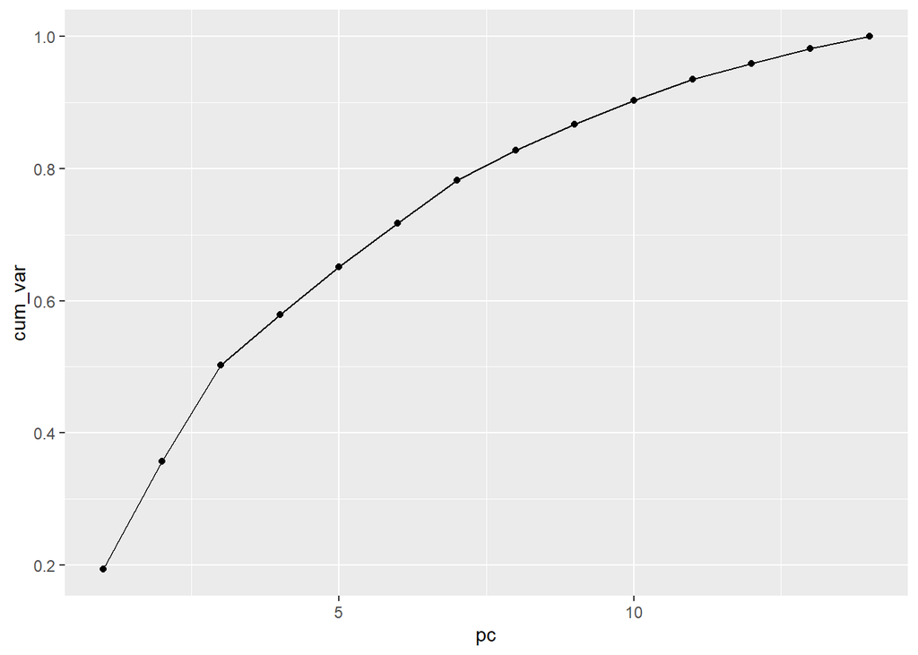

```r
ggplot(data.frame(pc=1:14,cum_var=c(0.1933541, 0.3571346, 0.5026248, 0.57892018, 0.6512518, 0.71726939, 0.78188972, 0.82759186, 0.86688253, 0.90265997, 0.93509576, 0.95916222, 0.98186244, 1.00000000)),aes(x=pc,y=cum_var)) +
  geom_point() +
  geom_line()
```

## 2.5. Multidimensional Scaling Analysis

```r
survey_mds_data <- survey_data[,sapply(survey_data,class)=="integer"] %>%
  select(History:Pets)
```

```r
survey_mds_distance <- 1 - cor(survey_mds_data)

survey_mds <- cmdscale(survey_mds_distance,k=2)

colnames(survey_mds) <- c("x","y")

print(survey_mds)
```

```
##                                   x            y
## History                 0.031306226 -0.057585867
## Psychology              0.221673919 -0.034255291
## Politics               -0.210706395  0.084207670
## Mathematics            -0.366106787 -0.301011922
## Physics                -0.338602615 -0.488946202
## Internet               -0.435984609  0.193575251
## PC                     -0.602886441 -0.104205122
## Economy Management     -0.313464728  0.369369369
## Biology                 0.249496019 -0.352229723
## Chemistry               0.111150203 -0.427188341
## Reading                 0.525002226 -0.036403993
## Geography              -0.082496760 -0.010735122
## Foreign languages       0.197742370  0.164499851
## Medicine                0.190107055 -0.319538506
## Law                    -0.091720302  0.234211611
## Cars                   -0.593017958  0.091655704
## Art exhibitions         0.380132671 -0.025937391
## Religion                0.177085206 -0.229380678
## Countryside, outdoors   0.159766147 -0.101417980
## Dancing                 0.326087243  0.151882648
## Musical instruments     0.165516710 -0.156630640
## Writing                 0.291051922 -0.065898705
## Passive sport          -0.288889494  0.153049302
## Active sport           -0.180541543  0.077474365
## Gardening               0.203069385 -0.051532921
## Celebrities             0.059109759  0.515094714
## Shopping                0.248971459  0.505415685
## Science and technology -0.368579088 -0.307211932
## Theatre                 0.452232345  0.006680821
## Fun with friends        0.002109219  0.282818197
## Adrenaline sports      -0.251016420  0.072054588
## Pets                    0.132403055  0.168120560
```

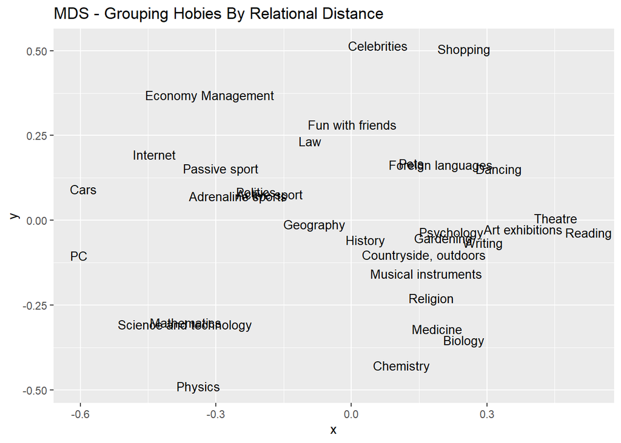

```r
ggplot(data.frame(survey_mds),aes(x=x,y=y)) +
  geom_text(label=rownames(survey_mds),size=3.5) +
  labs(x="x",y="y", title="MDS - Grouping Hobies By Relational Distance")
```

## 2.6. In Conclusion

To sum up, it can be said that;

- Celebrities- Shopping
- Active Sports- Adrenaline- Pssive Sports- Politics
- Science and technology- Mathematics
- Medicine-Biology-Chemistry
- countryside, Outdoors-History- Musical Instruments- Religion
- Art exhibitions- Theatre- Reading
- Foreign Language- Dancing
- Gardening- Psychology- Writing
- Geography-History

categories are the most relational to each other.

# 3. References

- [Young People Survey](https://www.kaggle.com/miroslavsabo/young-people-survey/data)
- [Adding percentage labels on pie chart in R](https://stackoverflow.com/questions/41338757/adding-percentage-labels-on-pie-chart-in-r)
- [Top 50 ggplot2 Visualizations](http://r-statistics.co/Top50-Ggplot2-Visualizations-MasterList-R-Code.html#Pie%20Chart)